# Temperature increase

Voyons maintenant ce qui se passe dans un site chaud et sec (Cottbus) :

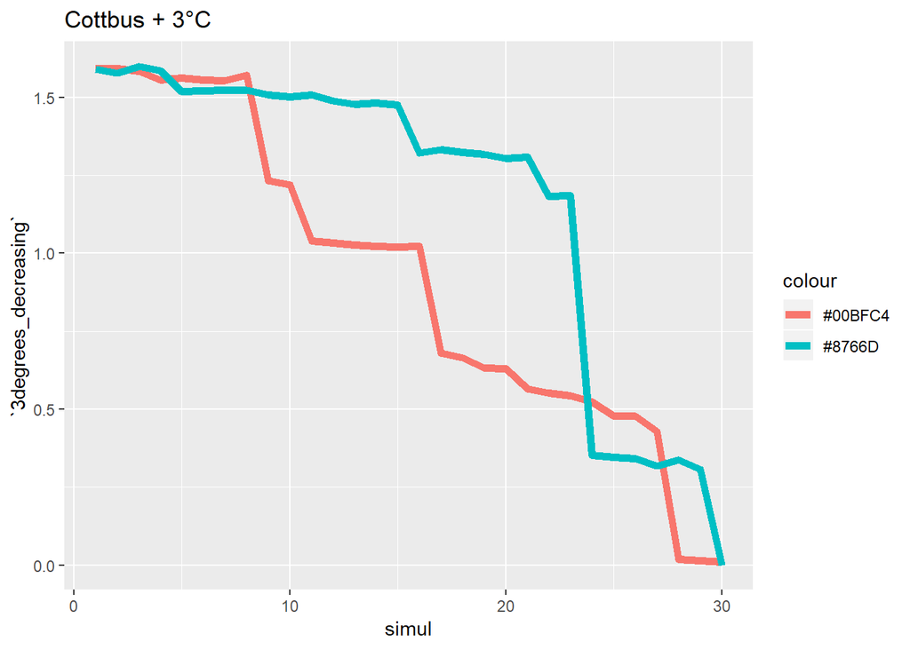

```r
graph_site("Cottbus","3degrees_increasing")
```

```r
# graph_site("Basel","3degrees_increasing")
```

On perd globalement de la productivité : on partait de 2 t/ha/an en températures normales, et à +3°C, on est plutôt à 1,6 t/ha/an. Mais on n’a pas augmenté la différence entre les deux courrbes ? (à vérifier quand j’aurai fait les random).

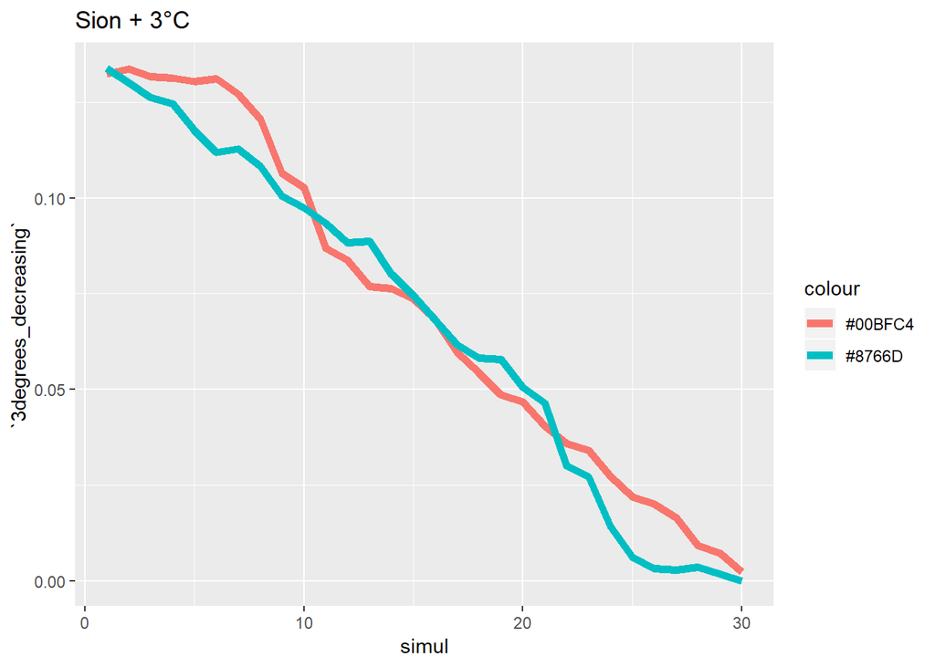

```r
graph_site("Sion","3degrees_increasing")
```

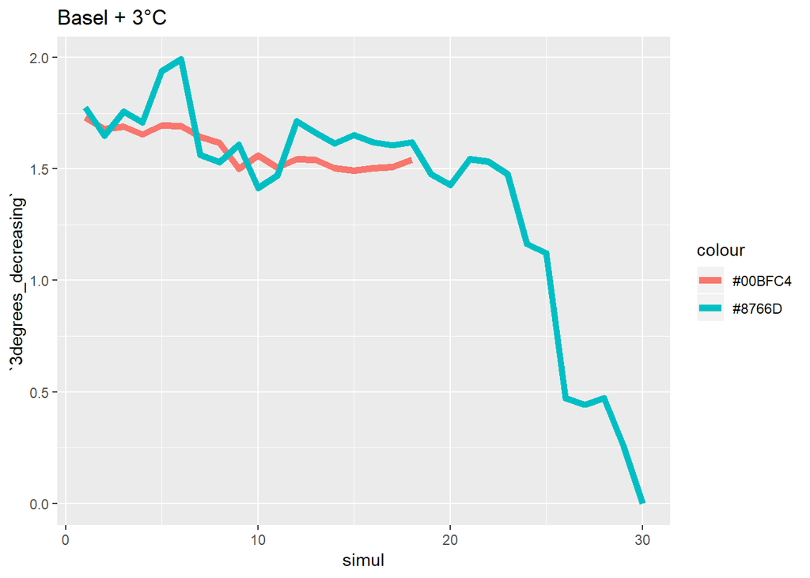

```r
graph_site("Basel","3degrees_increasing")
```

Basel est un site chaud et sec. Chelou ici: pourquoi je n’ai plus de productivité à partir de 18 espèces en moins ?